# Tests for data-generating mechanisms

Author

Stacy Cyrille

Published

March 4, 2026

```r
library(tidyverse)
library(MASS)
library(knitr)
library(survival)
library(timereg)

rprojroot <- rprojroot::find_rstudio_root_file()
source(file.path(rprojroot, "R/utils.R"))
source(file.path(rprojroot, "R/generate_data.R"))
```

## 1 DNA pathways

**Example 1**

We generate a simple example.

- Sample size: $n = 1000$
- Number of DNA pathways: $p = 3$
- Prevalence of DNA pathways: $\pi_1 = 0.1, \quad \pi_2 = 0.4, \quad \pi_3 = 0.6 \quad$
- Correlation matrix:

$$\Sigma_D = \left(
\begin{array}{ccc}
\text{1} & \text{0} & \text{0.2} \\
\text{0} & \text{1} & \text{0.5} \\
\text{0.2} & \text{0.5} & \text{1}
\end{array}
\right)$$

```r
set.seed(2026)

n <- 1000
prev <- c(0.1, 0.4, 0.6)

Sigma <- matrix(c(1,   0,   0.2,
                  0,   1,   0.5,
                  0.2, 0.5, 1),
                3, 3)

dna1 <- simulate_dna_pathways(n, prev, Sigma)
head(dna1)
```

```
  D1 D2 D3
1  0  1  1
2  0  0  0
3  0  1  1
4  0  0  0
5  0  0  0
6  0  0  0
```

```r
# Check prevalences
colMeans(dna1)
```

```
   D1    D2    D3
0.093 0.405 0.603
```

```r
# Check dependence (Fisher’s exact tests)
fisher.test(table(dna1$D1, dna1$D2))
```

```
    Fisher's Exact Test for Count Data

data:  table(dna1$D1, dna1$D2)
p-value = 1
alternative hypothesis: true odds ratio is not equal to 1
95 percent confidence interval:
 0.6397796 1.6015359
sample estimates:
odds ratio
  1.016585
```

```r
fisher.test(table(dna1$D1, dna1$D3))
```

```
    Fisher's Exact Test for Count Data

data:  table(dna1$D1, dna1$D3)
p-value = 5.081e-05
alternative hypothesis: true odds ratio is not equal to 1
95 percent confidence interval:
 1.628539 4.962215
sample estimates:
odds ratio
  2.780409
```

```r
fisher.test(table(dna1$D2, dna1$D3))
```

```
    Fisher's Exact Test for Count Data

data:  table(dna1$D2, dna1$D3)
p-value < 2.2e-16
alternative hypothesis: true odds ratio is not equal to 1
95 percent confidence interval:
 2.674120 4.802858
sample estimates:
odds ratio
  3.573428
```

**Example 2**

We generate only uncorrelated variables.

- Sample size:
  $$n = 1000$$
- Number of DNA pathways:
  $$p_D = 3$$
- Prevalence of DNA pathways: $\pi_1 = 0.1, \quad \pi_2 = 0.4, \quad \pi_3 = 0.6 \quad$
- Correlation matrix:

$$\Sigma_D = \left(
\begin{array}{ccc}
\text{1} & \text{0} & \text{0} \\
\text{0} & \text{1} & \text{0} \\
\text{0} & \text{0} & \text{1}
\end{array}
\right)$$

```r
set.seed(2026)
Sigma0 <- diag(3)
dna0 <- simulate_dna_pathways(n, prev, Sigma0)

# Check prevalences
colMeans(dna0)
```

```
   D1    D2    D3
0.111 0.409 0.591
```

```r
# Check dependence (Fisher’s exact tests)
fisher.test(table(dna0$D1, dna0$D2))
```

```
    Fisher's Exact Test for Count Data

data:  table(dna0$D1, dna0$D2)
p-value = 0.3061
alternative hypothesis: true odds ratio is not equal to 1
95 percent confidence interval:
 0.5128426 1.2159048
sample estimates:
odds ratio
 0.7941041
```

```r
fisher.test(table(dna0$D1, dna0$D3))
```

```
    Fisher's Exact Test for Count Data

data:  table(dna0$D1, dna0$D3)
p-value = 0.8379
alternative hypothesis: true odds ratio is not equal to 1
95 percent confidence interval:
 0.6966913 1.6274484
sample estimates:
odds ratio
  1.060629
```

```r
fisher.test(table(dna0$D2, dna0$D3))
```

```
    Fisher's Exact Test for Count Data

data:  table(dna0$D2, dna0$D3)
p-value = 0.3954
alternative hypothesis: true odds ratio is not equal to 1
95 percent confidence interval:
 0.6846429 1.1616203
sample estimates:
odds ratio
 0.8916356
```

**Example 3**

We simulate correlated variables grouped into blocks.

- Sample size: $n = 1000$
- Number of DNA pathways: $p_D = 20$
- Prevalence of DNA pathways: $\pi_{p_D} \sim \mathcal{U}(0.1, 0.6)$
- Block size: $b_D = 5$
- Number of blocks: $K_D = 4$
- Within-block correlations: $\rho_{D;k1} = 0.6, \quad \rho_{D;k2} = 0.5, \quad \rho_{D;k3} = 0.4, \quad \rho_{D;k4} = 0.1$
- Between-block correlation: $\rho_{B_D} = 0.05$

```r
set.seed(2026)
p <- 20

# Generate random prevalences
prev <- runif(20, 0.1, 0.6)
prev
```

```
 [1] 0.4493367 0.3782653 0.1700700 0.2428617 0.3776845 0.1125656 0.3331153
 [8] 0.5305053 0.2262506 0.3904032 0.1029666 0.4459330 0.2155625 0.5242662
[15] 0.1769176 0.2784047 0.3726023 0.1005988 0.2589122 0.1086447
```

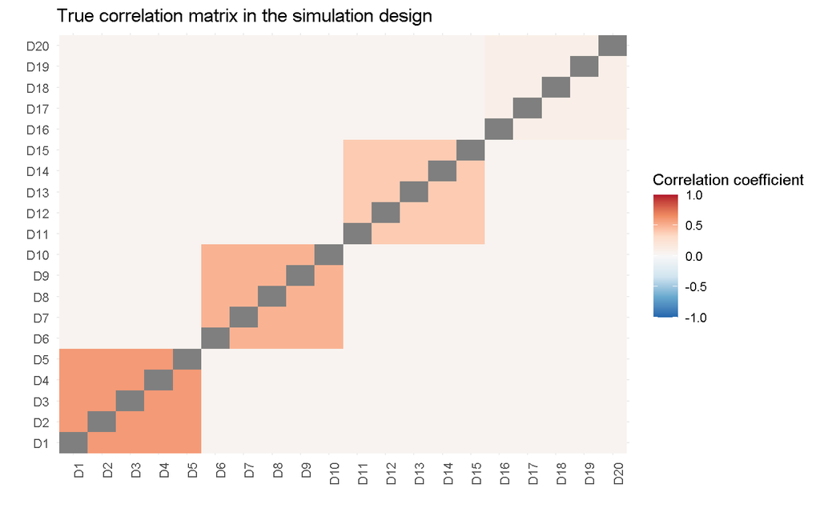

```r
# Initialize the matrix
Sigma <- generate_block_corr(p,
                             block_size = 5,
                             rho_within = c(0.6, 0.5, 0.4, 0.1),
                             rho_between = 0.05)
# Inspect the matrix
colnames(Sigma) <- paste0("D",1:p)
rownames(Sigma) <- paste0("D",1:p)
Sigma %>%
  as.data.frame()%>%
    tibble::rownames_to_column("var1")%>%
    pivot_longer(-var1, names_to = "var2")%>%
    mutate(value = ifelse(var1==var2, NA, value),
           var1 = factor(var1, levels = paste0("D",1:p)),
           var2 = factor(var2, levels = paste0("D",1:p)))%>%
    {
      ggplot(., aes(var1, var2, fill = value)) +
        geom_tile() +
        scale_fill_distiller(palette = "RdBu", direction = -1,
                             limits = c(-1,1)) +
        theme_minimal() +
        theme(axis.text.x = element_text(angle = 90, hjust = 1)) +
        labs(fill = "Correlation coefficient", x ="", y = "",
             title = "True correlation matrix in the simulation design")
    }
```

```r
# Simulate correlated data using this matrix
dna_block <- simulate_dna_pathways(n, prev, Sigma)

# Check marginal prevalences
data.frame(true_prev = prev,
           est_prev = colMeans(dna_block))%>%
  rownames_to_column("variable")%>%
  kable(format = "html", caption ="True and empirical prevalences",
        col.names = c("Variable","True prevalence","Estimated prevalence"))
```

True and empirical prevalences

| Variable | True prevalence | Estimated prevalence |
| --- | --- | --- |
| D1 | 0.4493367 | 0.463 |
| D2 | 0.3782653 | 0.367 |
| D3 | 0.1700700 | 0.161 |
| D4 | 0.2428617 | 0.226 |
| D5 | 0.3776845 | 0.371 |
| D6 | 0.1125656 | 0.119 |
| D7 | 0.3331153 | 0.298 |
| D8 | 0.5305053 | 0.523 |
| D9 | 0.2262506 | 0.199 |
| D10 | 0.3904032 | 0.376 |
| D11 | 0.1029666 | 0.119 |
| D12 | 0.4459330 | 0.434 |
| D13 | 0.2155625 | 0.207 |
| D14 | 0.5242662 | 0.522 |
| D15 | 0.1769176 | 0.189 |
| D16 | 0.2784047 | 0.287 |
| D17 | 0.3726023 | 0.372 |
| D18 | 0.1005988 | 0.105 |
| D19 | 0.2589122 | 0.247 |
| D20 | 0.1086447 | 0.122 |

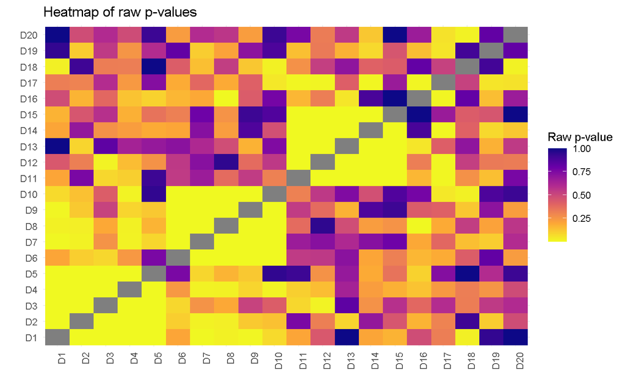

```r
# 20x20 matrix of raw p-values
pval_block <- pairwise_fisher(dna_block, names(dna_block))

# Heatmap of raw p-values
mat_long <- as.data.frame(as.table(pval_block$p.value.matrix))%>%
  mutate(Freq = ifelse(Var1==Var2, NA, Freq))
ggplot(mat_long, aes(Var1, Var2, fill = Freq)) +
  geom_tile() +
  scale_fill_viridis_c(option = "C", direction = -1) +
  theme_minimal() +
  theme(axis.text.x = element_text(angle = 90, hjust = 1)) +
  labs(fill = "Raw p-value", x ="", y = "",
       title = "Heatmap of raw p-values")
```

## 2 RNA pathways

**Example 1**

We generate a simple example.

- Sample size: $n = 1000$
- Number of RNA pathways: $p_R = 3$
- Correlation matrix:

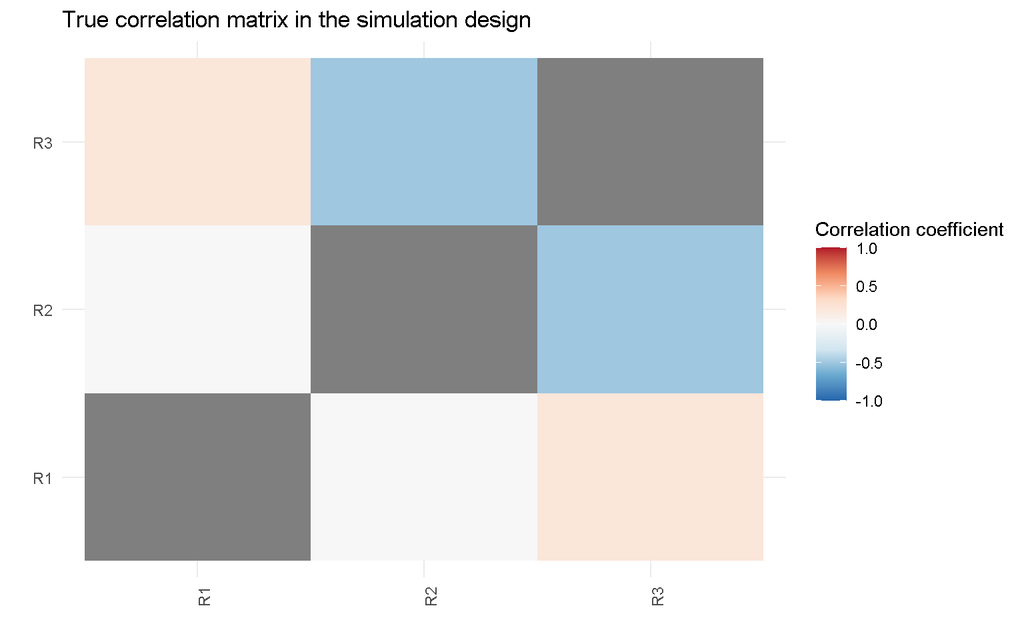

```r
set.seed(2026)
p <- 3
mu <- 0
Sigma <- matrix(c(1,   0,   0.2,
                  0,   1,   -0.5,
                  0.2, -0.5, 1),
                3, 3)
# Inspect the matrix
colnames(Sigma) <- paste0("R",1:p)
rownames(Sigma) <- paste0("R",1:p)
Sigma %>%
  as.data.frame()%>%
    tibble::rownames_to_column("var1")%>%
    pivot_longer(-var1, names_to = "var2")%>%
    mutate(value = ifelse(var1==var2, NA, value),
           var1 = factor(var1, levels = paste0("R",1:p)),
           var2 = factor(var2, levels = paste0("R",1:p)))%>%
    {
      ggplot(., aes(var1, var2, fill = value)) +
        geom_tile() +
        scale_fill_distiller(palette = "RdBu", direction = -1,
                             limits = c(-1,1)) +
        theme_minimal() +
        theme(axis.text.x = element_text(angle = 90, hjust = 1)) +
        labs(fill = "Correlation coefficient", x ="", y = "",
             title = "True correlation matrix in the simulation design")
    }
```

```r
rna1 <- simulate_rna_pathways(n, p, mu, Sigma)

# Check mean
colMeans(rna1)
```

```
           R1            R2            R3
-2.063280e-17 -3.625572e-19 -1.562032e-17
```

```r
# Check variance
apply(rna1, 2, var)
```

```
R1 R2 R3
 1  1  1
```

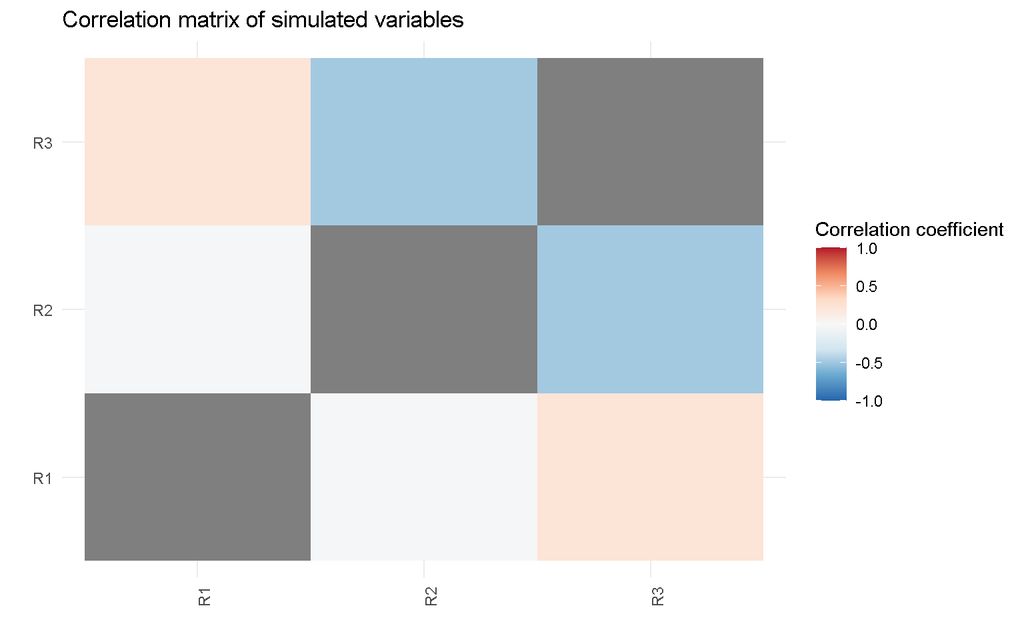

```r
# Correlation matrix
as.data.frame(cor(rna1))%>%
  tibble::rownames_to_column("var1")%>%
  pivot_longer(-var1, names_to = "var2")%>%
  mutate(value = ifelse(var1==var2, NA, value),
         var1 = factor(var1, levels = paste0("R",1:20)),
         var2 = factor(var2, levels = paste0("R",1:20)))%>%
  {
    ggplot(., aes(var1, var2, fill = value)) +
      geom_tile() +
      scale_fill_distiller(palette = "RdBu", direction = -1,
                           limits = c(-1,1)) +
      theme_minimal() +
      theme(axis.text.x = element_text(angle = 90, hjust = 1)) +
      labs(fill = "Correlation coefficient", x ="", y = "",
           title = "Correlation matrix of simulated variables")
  }
```

**Example 2**

We simulate correlated variables grouped into blocks.

- Sample size: $n = 1000$
- Number of RNA pathways $p_R = 20$
- Block size: $b_R = 5$
- Number of blocks: $K_R = 4$
- Within-block correlations: $\rho_{R;k1} = 0.7, \quad \rho_{R;k2} = -0.2, \quad \rho_{R;k3} = 0.5, \quad \rho_{R;k4} = 0.1$
- Between-block correlation: $\rho_{B_R} = 0.05$

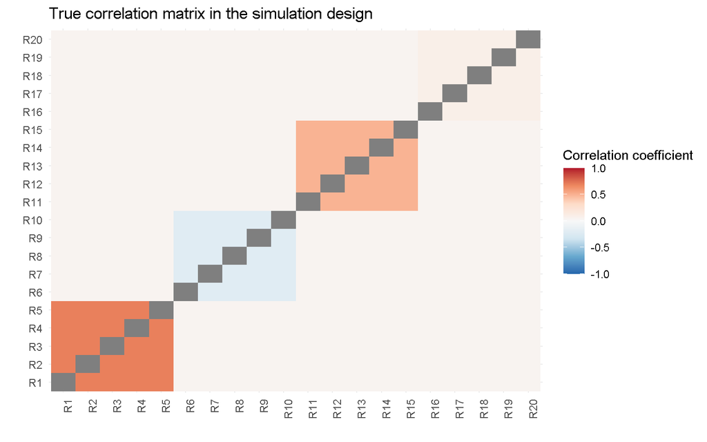

```r
set.seed(2026)
p = 20

# Initialize the matrix
Sigma <- generate_block_corr(p,
                             block_size = 5,
                             rho_within = c(0.7, -0.2, 0.5, 0.1),
                             rho_between = 0.05)
# Inspect the matrix
colnames(Sigma) <- paste0("R",1:20)
rownames(Sigma) <- paste0("R",1:20)
Sigma %>%
  as.data.frame()%>%
    tibble::rownames_to_column("var1")%>%
    pivot_longer(-var1, names_to = "var2")%>%
    mutate(value = ifelse(var1==var2, NA, value),
           var1 = factor(var1, levels = paste0("R",1:20)),
           var2 = factor(var2, levels = paste0("R",1:20)))%>%
    {
      ggplot(., aes(var1, var2, fill = value)) +
        geom_tile() +
        scale_fill_distiller(palette = "RdBu", direction = -1,
                             limits = c(-1,1)) +
        theme_minimal() +
        theme(axis.text.x = element_text(angle = 90, hjust = 1)) +
        labs(fill = "Correlation coefficient", x ="", y = "",
             title = "True correlation matrix in the simulation design")
    }
```

```r
# Simulate correlated data using this matrix
rna_block <- simulate_rna_pathways(n, p, mu, Sigma)

# Check mean
colMeans(rna_block)
```

```
           R1            R2            R3            R4            R5
 1.482950e-17  2.079370e-17  1.660477e-17 -2.885799e-17  2.405021e-17
           R6            R7            R8            R9           R10
 1.358288e-17  2.560452e-18 -1.540261e-17 -2.506675e-17  5.332540e-18
          R11           R12           R13           R14           R15
 3.231530e-17  1.650589e-18  1.955641e-17 -2.100750e-18 -1.665855e-17
          R16           R17           R18           R19           R20
-1.226883e-17 -1.480554e-17 -1.961972e-17 -4.916206e-18 -4.945697e-18
```

```r
# Check variance
apply(rna_block, 2, var)
```

```
 R1  R2  R3  R4  R5  R6  R7  R8  R9 R10 R11 R12 R13 R14 R15 R16 R17 R18 R19 R20
  1   1   1   1   1   1   1   1   1   1   1   1   1   1   1   1   1   1   1   1
```

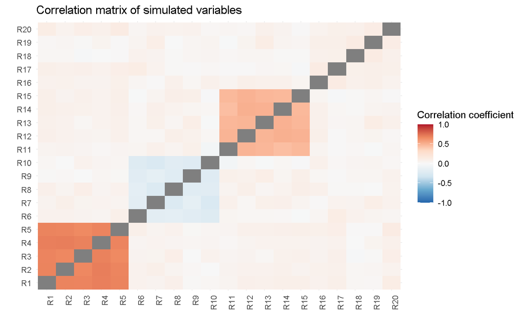

```r
# Correlation matrix
as.data.frame(cor(rna_block))%>%
  tibble::rownames_to_column("var1")%>%
  pivot_longer(-var1, names_to = "var2")%>%
  mutate(value = ifelse(var1==var2, NA, value),
         var1 = factor(var1, levels = paste0("R",1:20)),
         var2 = factor(var2, levels = paste0("R",1:20)))%>%
  {
    ggplot(., aes(var1, var2, fill = value)) +
      geom_tile() +
      scale_fill_distiller(palette = "RdBu", direction = -1,
                           limits = c(-1,1)) +
      theme_minimal() +
      theme(axis.text.x = element_text(angle = 90, hjust = 1)) +
      labs(fill = "Correlation coefficient", x ="", y = "",
           title = "Correlation matrix of simulated variables")
  }
```

## 3 Aalen model

```r
# Set seed for reproducibility
set.seed(2026)

# Sample size
n <- 1000

# Generate covariates
p <- 3
Sigma <- matrix(c(1, 0, 0,
                  0, 1, 0,
                  0, 0, 1),
                3, 3)
X <- as.matrix(simulate_rna_pathways(n, p, mu = 0, Sigma))

# Generate time to event data
beta <- c(0, 0.02, 0.06)
lambda0 <- 0.07
lambda_i <- lambda0 + drop(X %*% beta)
lambda_i <- pmax(lambda_i, 1e-8)
T <- rexp(n, rate = lambda_i)
cens_rate <- 0.05
C <- rexp(n, rate = cens_rate)
time <- pmin(T, C)
event <- as.integer(T <= C)
data <- data.frame(time, event, X)

# Fit the Aalen model
# All components of the model have nonparametric time-varying effects.
aalen_fit <- timereg::aalen(Surv(time, event)~R1+R2+R3,
                            data = data)
summary(aalen_fit)
```

```
Additive Aalen Model

Test for nonparametric terms

Test for non-significant effects
            Supremum-test of significance p-value H_0: B(t)=0
(Intercept)                         18.10               0.000
R1                                   1.68               0.843
R2                                   4.90               0.000
R3                                  14.40               0.000

Test for time invariant effects
                  Kolmogorov-Smirnov test p-value H_0:constant effect
(Intercept)                        0.4020                       0.240
R1                                 0.0585                       0.776
R2                                 0.1750                       0.309
R3                                 0.3110                       0.155
                    Cramer von Mises test p-value H_0:constant effect
(Intercept)                        2.0200                       0.231
R1                                 0.0476                       0.636
R2                                 0.3280                       0.371
R3                                 1.3100                       0.135



  Call:
timereg::aalen(formula = Surv(time, event) ~ R1 + R2 + R3, data = data)
```

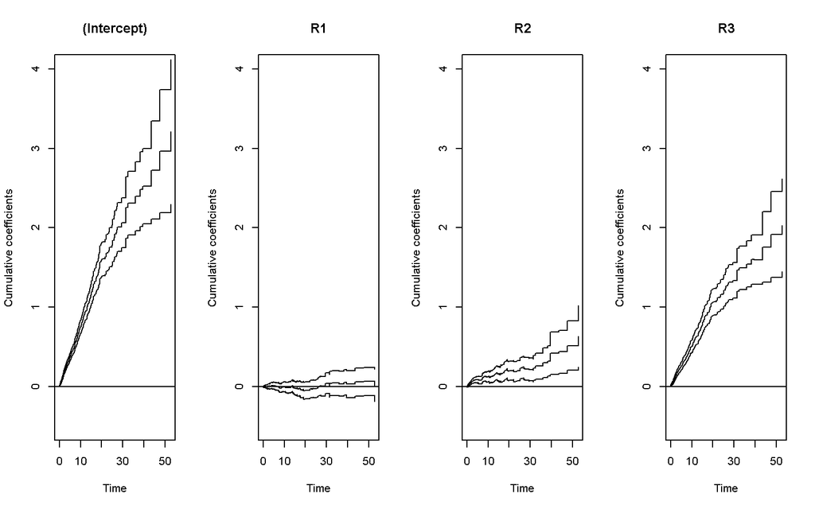

```r
# Plot the non-parametric cumulative regression coefficients with 95% CI
par(mfrow=c(1,4))
plot(aalen_fit, ylim = c(-0.5,4))
```

```r
# Fit the model with the effect of R1 being constant
aalen_fit2 <- timereg::aalen(Surv(time, event)~const(R1)+R2+R3,
                            data = data)
summary(aalen_fit2)
```

```
Additive Aalen Model

Test for nonparametric terms

Test for non-significant effects
            Supremum-test of significance p-value H_0: B(t)=0
(Intercept)                         18.10                   0
R2                                   4.91                   0
R3                                  14.40                   0

Test for time invariant effects
                  Kolmogorov-Smirnov test p-value H_0:constant effect
(Intercept)                         0.387                       0.293
R2                                  0.190                       0.280
R3                                  0.301                       0.191
                    Cramer von Mises test p-value H_0:constant effect
(Intercept)                         1.820                       0.271
R2                                  0.417                       0.325
R3                                  1.090                       0.209

Parametric terms :
              Coef.      SE Robust SE      z P-val lower2.5% upper97.5%
const(R1) -0.000256 0.00217   0.00216 -0.119 0.906  -0.00451      0.004

  Call:
timereg::aalen(formula = Surv(time, event) ~ const(R1) + R2 +
    R3, data = data)
```

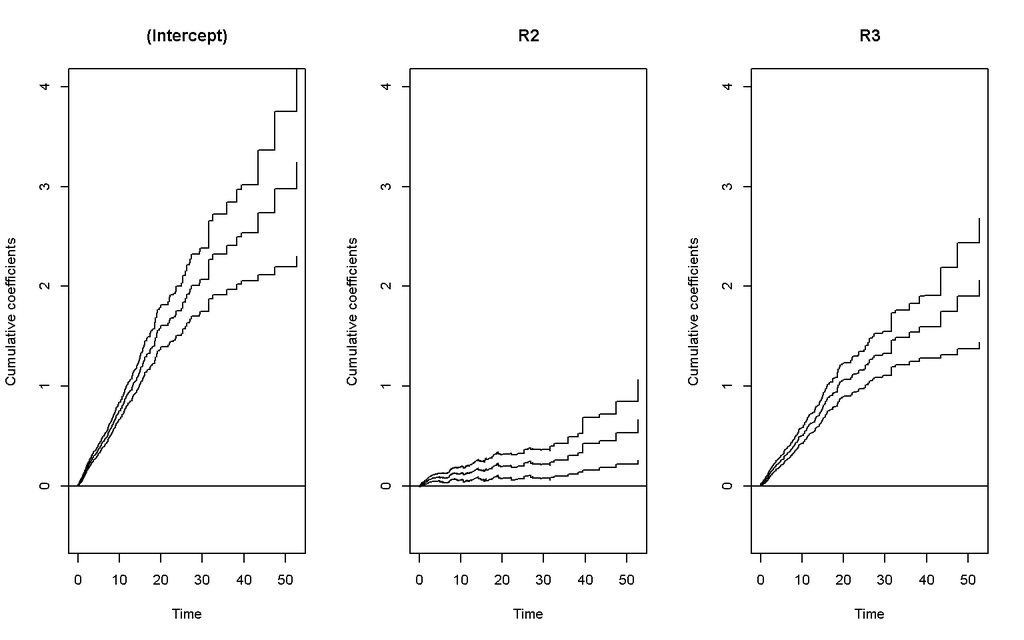

```r
par(mfrow=c(1,3))
plot(aalen_fit2, ylim = c(-0.5,4))
```

## 4 Cox-Aalen model

```r
# Set seed for reproducibility
set.seed(2026)

# Sample size
n <- 1000

# Generate covariates
p <- 2
prev <- c(0.2, 0.5)
Sigma <- matrix(c(1, 0,
                  0, 1),
                p, p)
X_D <- simulate_dna_pathways(n, prev, Sigma)
X_R <- simulate_rna_pathways(n, p, mu = 0, Sigma)
X <- cbind(X_D, X_R)

# Generate time to event data
beta_add <- c(0, 0.04)
beta_mult <- c(0.7, 0)
lambda0 <- 0.05
cens_rate <- 0.05
hazard_i <- lambda0 * exp(drop(as.matrix(X_D) %*% beta_mult))+
  drop(as.matrix(X_R) %*% beta_add)
hazard_i <- pmax(hazard_i, 1e-6)
T <- rexp(n, rate = hazard_i)
C <- rexp(n, rate = cens_rate)
time <- pmin(T, C)
event <- as.integer(T<=C)
data <- data.frame(time, event, X_D, X_R)

# Fit Cox Aalen model
cox_aalen_fit <- timereg::cox.aalen(
  Surv(time, event)~prop(D1)+prop(D2)+R1+R2,
  data)
summary(cox_aalen_fit)
```

```
Cox-Aalen Model

Test for Aalen terms
Test not computed, sim=0

Proportional Cox terms :
           Coef.     SE Robust SE D2log(L)^-1      z    P-val lower2.5%
prop(D1)  0.7550 0.1090     0.110      0.1090  6.850 7.40e-12     0.541
prop(D2) -0.0277 0.0927     0.093      0.0929 -0.298 7.66e-01    -0.209
         upper97.5%
prop(D1)      0.969
prop(D2)      0.154
Test of Proportionality
         sup|  hat U(t) | p-value H_0
prop(D1)             4.95        0.830
prop(D2)             7.32        0.628
```

```r
# Proportional excess terms of model
cox(cox_aalen_fit)
```

```
Cox-Aalen Model

Test for Aalen terms
Test not computed, sim=0

Proportional Cox terms :
           Coef.     SE Robust SE D2log(L)^-1      z    P-val lower2.5%
prop(D1)  0.7550 0.1090     0.110      0.1090  6.850 7.40e-12     0.541
prop(D2) -0.0277 0.0927     0.093      0.0929 -0.298 7.66e-01    -0.209
         upper97.5%
prop(D1)      0.969
prop(D2)      0.154
Test of Proportionality
         sup|  hat U(t) | p-value H_0
prop(D1)             4.95        0.830
prop(D2)             7.32        0.628
```

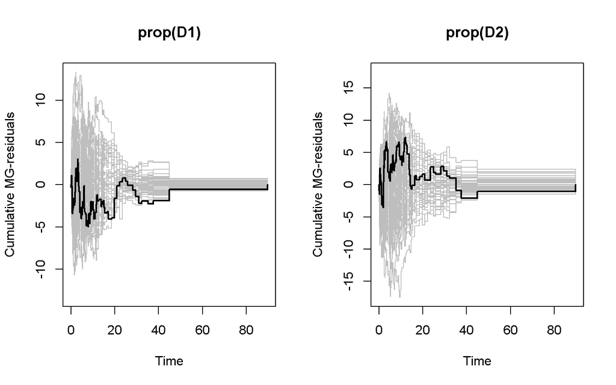

```r
par(mfrow=c(1,2))
plot(cox_aalen_fit,score= TRUE)
```

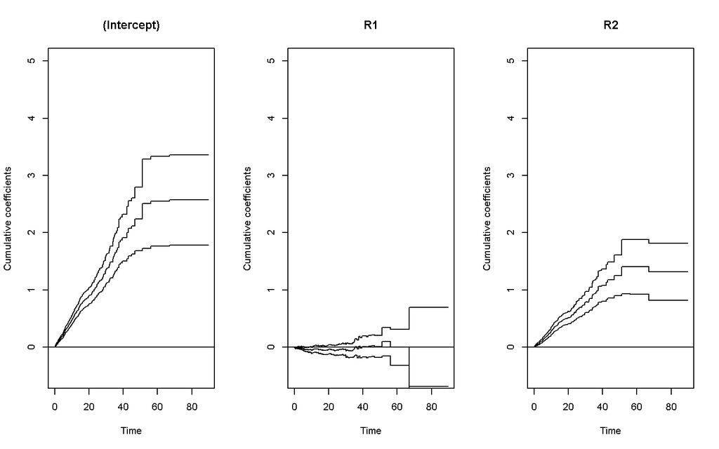

```r
# Plot additive Aalen terms
par(mfrow = c(1,3))
plot(cox_aalen_fit, ylim = c(-0.5,5))
```

```r
# Allow some additive terms to be time-constant
cox_aalen_fit2 <- timereg::cox.aalen(
  Surv(time, event)~prop(D1)+prop(D2)+const(R1)+R2,
  data, robust = TRUE)
summary(cox_aalen_fit2)
```

```
Cox-Aalen Model

Test for Aalen terms
Test not computed, sim=0

Proportional Cox terms :
           Coef.     SE Robust SE D2log(L)^-1      z    P-val lower2.5%
prop(D1)  0.7550 0.1090     0.110      0.1090  6.850 7.40e-12     0.541
prop(D2) -0.0277 0.0927     0.093      0.0929 -0.298 7.66e-01    -0.209
         upper97.5%
prop(D1)      0.969
prop(D2)      0.154
Test of Proportionality
         sup|  hat U(t) | p-value H_0
prop(D1)             4.95        0.818
prop(D2)             7.32        0.636
```

```r
# Proportional excess terms of model
cox(cox_aalen_fit2)
```

```
Cox-Aalen Model

Test for Aalen terms
Test not computed, sim=0

Proportional Cox terms :
           Coef.     SE Robust SE D2log(L)^-1      z    P-val lower2.5%
prop(D1)  0.7550 0.1090     0.110      0.1090  6.850 7.40e-12     0.541
prop(D2) -0.0277 0.0927     0.093      0.0929 -0.298 7.66e-01    -0.209
         upper97.5%
prop(D1)      0.969
prop(D2)      0.154
Test of Proportionality
         sup|  hat U(t) | p-value H_0
prop(D1)             4.95        0.818
prop(D2)             7.32        0.636
```

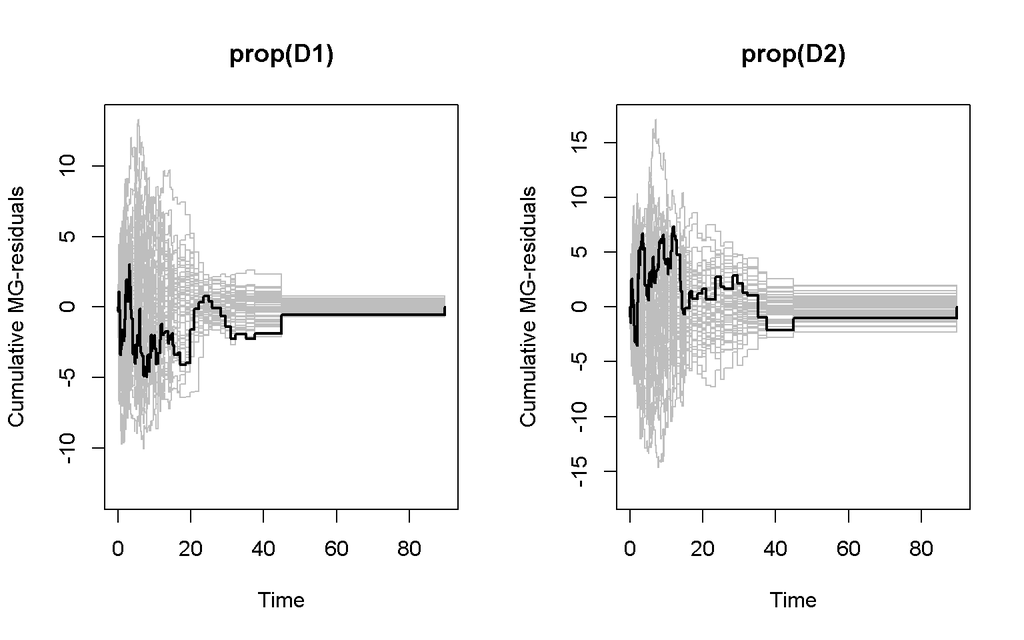

```r
par(mfrow=c(1,2))
plot(cox_aalen_fit2,score= TRUE)
```

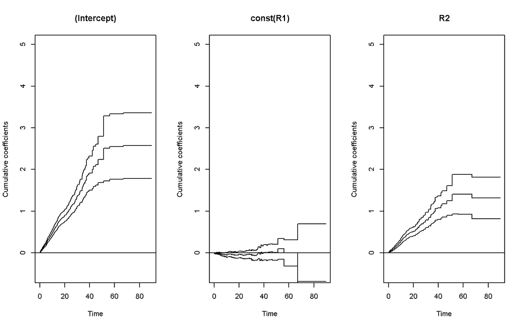

```r
# Plot additive Aalen terms
par(mfrow = c(1,3))
plot(cox_aalen_fit2, ylim = c(-0.5, 5))
```